# 4264_Final_Hackathon : Auto Insurance Claim

## Business Case

As we relate to Insurance business, these days lot of insurance companies are dealing with the problem of fraudulent claims.

Fraud affects the lives of innocent people as well as the insurance industry as industry faces the losses and as a result of which peoples need to suffer by increased premiums. Thus we can say, it may be of interest for the health of the Insurance Industry and Society.

Insurance fraud claim refers to any claim which intent to obtain an improper payment from an insurer.

Auto insurance fraud includes: misrepresenting facts on an insurance application; submitting claims for injuries or damage that never occurred; staging accidents; and also false reports of stolen vehicles.

According to the FBI (Federal Bureau of Investigation), non-health insurance fraud costs an estimated 40 billion doller per year, which means Insurance Fraud cost the average U.S. family between 400 doller and 700 doller per year in the form of increased premiums. (source: https://www.fbi.gov/stats-services/publications/insurance-fraud)

So to overcome this, the manual procedure of analyzing vehicle insurance claims necessitates the hiring of highly skilled fraud reviewers, which makes detecting fraud time-consuming, expensive, and unscalable as the number of claims increases.

Machine Learning can be used, among other tools, to uncover fraud before a payment. These newer strategies are employed when claims are initially filed. Suspicious claims are flagged for further review, while those with no apparent questionable elements are processed normally.

The framework of prediction of fraud and pattern extraction wil be useful for the insurance companies, regulatory body, intelligence department etc.

## Problem Statement

The goal of this hackathon project is to build a generalized model that can detect whether the claim of auto insurance is fraudulent or not(legit). The challenge behind fraud detection in machine learning is that frauds are far less common as compared to legit insurance claims. This type of problems is known as imbalanced class classification. So by building a model that can classify auto insurance fraud, I am able to cut losses for the insurance company. Fewer losses equates to more earning to the business of Insurance company..

## About The Dataset

1. Demographics Data : These files consist of the demographic data of each customer, like CustomerID, Country,InsuredAge, InsuredGender, InsuredEducationLevel,etc .
2. Policy Information : These files consist of the customer auto insurance policy information, connected to the claim with the insurance company, like, CustomerID, InsurancePolicyNumber, DateOfPolicyCoverage, InsurancePolicyState, UmbrellaLimit, etc.
3. Data of Claim : These files consist of the details about the insurance claim, that the customer applied for, like DateOfIncident, TypeOfIncident, AmountOfInjuryclaim, AmountOfPropertyClaim, etc.
4. Data of Vehicle : These files consist of the details about the Vehicle, connected to the policy.
5. Fraud Data : This contains the Fraud information details, like CustomerID, ReportedFraud.

## Importing Libraries

```python
## Importing data pre-processing libraries and ML models.

import pandas as pd
import numpy as np
import seaborn as sns
import matplotlib.pyplot as plt

from sklearn.preprocessing import StandardScaler

from sklearn.model_selection import train_test_split, RandomizedSearchCV
from sklearn.linear_model import LogisticRegression
from sklearn.neighbors import KNeighborsClassifier
from sklearn.svm import SVC
from sklearn.tree import DecisionTreeClassifier
from sklearn.ensemble import RandomForestClassifier
from xgboost import XGBClassifier

from sklearn import metrics
from sklearn.metrics import classification_report
from sklearn.metrics import confusion_matrix

%matplotlib inline
```

## Loading the dataset

```python
# Loading Trainclaim.csv dataset and checking shape and head.

Claim_csv = pd.read_csv("Train_Claim.csv")
print(Claim_csv.shape)
Claim_csv.head()
```

```
(28836, 19)
```

|  | CustomerID | DateOfIncident | TypeOfIncident | TypeOfCollission | SeverityOfIncident | AuthoritiesContacted | IncidentState | IncidentCity | IncidentAddress | IncidentTime | NumberOfVehicles | PropertyDamage | BodilyInjuries | Witnesses | PoliceReport | AmountOfTotalClaim | AmountOfInjuryClaim | AmountOfPropertyClaim | AmountOfVehicleDamage |
| --- | --- | --- | --- | --- | --- | --- | --- | --- | --- | --- | --- | --- | --- | --- | --- | --- | --- | --- | --- |
| 0 | Cust10000 | 2015-02-03 | Multi-vehicle Collision | Side Collision | Total Loss | Police | State7 | City1 | Location 1311 | 17 | 3 | ? | 1 | 0 | ? | 65501 | 13417 | 6071 | 46013 |
| 1 | Cust10001 | 2015-02-02 | Multi-vehicle Collision | Side Collision | Total Loss | Police | State7 | City5 | Location 1311 | 10 | 3 | YES | 2 | 1 | YES | 61382 | 15560 | 5919 | 39903 |
| 2 | Cust10002 | 2015-01-15 | Single Vehicle Collision | Side Collision | Minor Damage | Other | State8 | City6 | Location 2081 | 22 | 1 | YES | 2 | 3 | NO | 66755 | 11630 | 11630 | 43495 |
| 3 | Cust10003 | 2015-01-19 | Single Vehicle Collision | Side Collision | Minor Damage | Other | State9 | City6 | Location 2081 | 22 | 1 | YES | 2 | 3 | NO | 66243 | 12003 | 12003 | 42237 |
| 4 | Cust10004 | 2015-01-09 | Single Vehicle Collision | Rear Collision | Minor Damage | Fire | State8 | City6 | Location 1695 | 10 | 1 | NO | 2 | 1 | YES | 53544 | 8829 | 7234 | 37481 |

```python
# Loading Train_Demographics.csv dataset and checking shape and head.

Demographics_csv = pd.read_csv("Train_Demographics.csv")
print(Demographics_csv.shape)
Demographics_csv.head()
```

```
(28836, 10)
```

|  | CustomerID | InsuredAge | InsuredZipCode | InsuredGender | InsuredEducationLevel | InsuredOccupation | InsuredHobbies | CapitalGains | CapitalLoss | Country |
| --- | --- | --- | --- | --- | --- | --- | --- | --- | --- | --- |
| 0 | Cust10000 | 35 | 454776 | MALE | JD | armed-forces | movies | 56700 | -48500 | India |
| 1 | Cust10001 | 36 | 454776 | MALE | JD | tech-support | cross-fit | 70600 | -48500 | India |
| 2 | Cust10002 | 33 | 603260 | MALE | JD | armed-forces | polo | 66400 | -63700 | India |
| 3 | Cust10003 | 36 | 474848 | MALE | JD | armed-forces | polo | 47900 | -73400 | India |
| 4 | Cust10004 | 29 | 457942 | FEMALE | High School | exec-managerial | dancing | 0 | -41500 | India |

```python
# Loading Train_Policy.csv dataset and checking shape and head.

Policy_csv = pd.read_csv("Train_Policy.csv")
print(Policy_csv.shape)
Policy_csv.head()
```

```
(28836, 10)
```

|  | InsurancePolicyNumber | CustomerLoyaltyPeriod | DateOfPolicyCoverage | InsurancePolicyState | Policy_CombinedSingleLimit | Policy_Deductible | PolicyAnnualPremium | UmbrellaLimit | InsuredRelationship | CustomerID |
| --- | --- | --- | --- | --- | --- | --- | --- | --- | --- | --- |
| 0 | 110122 | 328 | 2014-10-17 | State3 | 250/500 | 1000 | 1406.91 | 0 | husband | Cust1001 |
| 1 | 110125 | 256 | 1990-05-25 | State1 | 250/500 | 2000 | 1415.74 | 6000000 | unmarried | Cust1004 |
| 2 | 110126 | 228 | 2014-06-06 | State1 | 500/1000 | 1000 | 1583.91 | 6000000 | unmarried | Cust1005 |
| 3 | 110127 | 256 | 2006-10-12 | State3 | 250/500 | 1000 | 1351.10 | 0 | unmarried | Cust1006 |
| 4 | 110128 | 137 | 2000-06-04 | State2 | 250/500 | 1000 | 1333.35 | 0 | husband | Cust1007 |

```python
# Loading Train_Vehicle.csv dataset and checking shape and head.

Vehicle_csv = pd.read_csv("Train_Vehicle.csv")
print(Vehicle_csv.shape)
Vehicle_csv.head()
```

```
(115344, 3)
```

|  | CustomerID | VehicleAttribute | VehicleAttributeDetails |
| --- | --- | --- | --- |
| 0 | Cust20179 | VehicleID | Vehicle8898 |
| 1 | Cust21384 | VehicleModel | Malibu |
| 2 | Cust33335 | VehicleMake | Toyota |
| 3 | Cust27118 | VehicleModel | Neon |
| 4 | Cust13038 | VehicleID | Vehicle30212 |

```python
# Loading Traindata_with_Target.csv dataset and checking shape and head.

Target_csv = pd.read_csv("Traindata_with_Target.csv")
print(Target_csv.shape)
Target_csv.head()
```

```
(28836, 2)
```

|  | CustomerID | ReportedFraud |
| --- | --- | --- |
| 0 | Cust20065 | N |
| 1 | Cust37589 | N |
| 2 | Cust24312 | N |
| 3 | Cust5493 | Y |
| 4 | Cust7704 | Y |

Note: We need to merge all the dataset to make a final dataset on the common feature among all ,ie., CustomerID. But before that, we can observe that Vehicle_csv is not having same number of rows like other datasets. So we need to try to use some method to make its rows equal to other dataset, so only we can perform merge operation here. I have used here Pivot table() which helped me in achieving the same number of rows as it created new features like VehicleID, VehicleMake, VehicleModel and VehicleYOM.

```python
Vehicle_csv1= (Vehicle_csv.pivot_table("VehicleAttributeDetails",["CustomerID"],"VehicleAttribute",aggfunc="first").reset_index().rename_axis(columns=None))
print(Vehicle_csv1.shape)
Vehicle_csv1.head()
```

```
(28836, 5)
```

|  | CustomerID | VehicleID | VehicleMake | VehicleModel | VehicleYOM |
| --- | --- | --- | --- | --- | --- |
| 0 | Cust10000 | Vehicle26917 | Audi | A5 | 2008 |
| 1 | Cust10001 | Vehicle15893 | Audi | A5 | 2006 |
| 2 | Cust10002 | Vehicle5152 | Volkswagen | Jetta | 1999 |
| 3 | Cust10003 | Vehicle37363 | Volkswagen | Jetta | 2003 |
| 4 | Cust10004 | Vehicle28633 | Toyota | CRV | 2010 |

## Merging the dataset

```python
print(Claim_csv.shape)
print(Demographics_csv.shape)
print(Policy_csv.shape)
print(Vehicle_csv1.shape)
print(Target_csv.shape)
```

```
(28836, 19)
(28836, 10)
(28836, 10)
(28836, 5)
(28836, 2)
```

```python
merge1 = pd.merge(Claim_csv, Demographics_csv, on='CustomerID')
merge2 = pd.merge(Policy_csv, Vehicle_csv1, on='CustomerID')
merge3 = pd.merge(merge2, Target_csv, on='CustomerID')
df = pd.merge(merge1, merge3, on='CustomerID')                 # df is final merged dataframe.
```

```python
df.head()
```

|  | CustomerID | DateOfIncident | TypeOfIncident | TypeOfCollission | SeverityOfIncident | AuthoritiesContacted | IncidentState | IncidentCity | IncidentAddress | IncidentTime | ... | Policy_CombinedSingleLimit | Policy_Deductible | PolicyAnnualPremium | UmbrellaLimit | InsuredRelationship | VehicleID | VehicleMake | VehicleModel | VehicleYOM | ReportedFraud |
| --- | --- | --- | --- | --- | --- | --- | --- | --- | --- | --- | --- | --- | --- | --- | --- | --- | --- | --- | --- | --- | --- |
| 0 | Cust10000 | 2015-02-03 | Multi-vehicle Collision | Side Collision | Total Loss | Police | State7 | City1 | Location 1311 | 17 | ... | 100/300 | 1000 | 1632.73 | 0 | not-in-family | Vehicle26917 | Audi | A5 | 2008 | N |
| 1 | Cust10001 | 2015-02-02 | Multi-vehicle Collision | Side Collision | Total Loss | Police | State7 | City5 | Location 1311 | 10 | ... | 100/300 | 1000 | 1255.19 | 0 | not-in-family | Vehicle15893 | Audi | A5 | 2006 | N |
| 2 | Cust10002 | 2015-01-15 | Single Vehicle Collision | Side Collision | Minor Damage | Other | State8 | City6 | Location 2081 | 22 | ... | 500/1000 | 617 | 1373.38 | 0 | wife | Vehicle5152 | Volkswagen | Jetta | 1999 | N |
| 3 | Cust10003 | 2015-01-19 | Single Vehicle Collision | Side Collision | Minor Damage | Other | State9 | City6 | Location 2081 | 22 | ... | 500/1000 | 722 | 1337.60 | 0 | own-child | Vehicle37363 | Volkswagen | Jetta | 2003 | N |
| 4 | Cust10004 | 2015-01-09 | Single Vehicle Collision | Rear Collision | Minor Damage | Fire | State8 | City6 | Location 1695 | 10 | ... | 100/300 | 500 | 1353.73 | 4279863 | unmarried | Vehicle28633 | Toyota | CRV | 2010 | N |

5 rows × 42 columns

```python
df.tail()
```

|  | CustomerID | DateOfIncident | TypeOfIncident | TypeOfCollission | SeverityOfIncident | AuthoritiesContacted | IncidentState | IncidentCity | IncidentAddress | IncidentTime | ... | Policy_CombinedSingleLimit | Policy_Deductible | PolicyAnnualPremium | UmbrellaLimit | InsuredRelationship | VehicleID | VehicleMake | VehicleModel | VehicleYOM | ReportedFraud |
| --- | --- | --- | --- | --- | --- | --- | --- | --- | --- | --- | --- | --- | --- | --- | --- | --- | --- | --- | --- | --- | --- |
| 28831 | Cust9993 | 2015-01-24 | Vehicle Theft | ? | Trivial Damage | Police | State9 | City4 | Location 1890 | 3 | ... | 500/1000 | 655 | 1276.01 | 0 | unmarried | Vehicle13568 | Suburu | Impreza | 2007 | N |
| 28832 | Cust9994 | 2015-02-09 | Single Vehicle Collision | Front Collision | Minor Damage | Fire | State8 | City3 | Location 2097 | 17 | ... | 100/300 | 1089 | 1273.38 | 0 | unmarried | Vehicle19810 | Jeep | Wrangler | 2003 | N |
| 28833 | Cust9996 | 2015-01-28 | Single Vehicle Collision | Rear Collision | Minor Damage | Fire | State9 | City7 | Location 1452 | 1 | ... | 250/500 | 787 | 1380.92 | 3448735 | own-child | Vehicle3339 | Suburu | Legacy | 2004 | N |
| 28834 | Cust9997 | 2015-01-28 | Single Vehicle Collision | Rear Collision | Minor Damage | Ambulance | State9 | City3 | Location 1876 | 1 | ... | 250/500 | 780 | 1389.29 | 3364301 | not-in-family | Vehicle10240 | Suburu | Forrestor | 2004 | N |
| 28835 | Cust9999 | 2015-01-13 | Single Vehicle Collision | Front Collision | Total Loss | Other | State8 | City3 | Location 1874 | 9 | ... | 500/1000 | 2000 | 928.43 | 2909175 | husband | Vehicle39163 | Suburu | E400 | 2007 | N |

5 rows × 42 columns

```python
df.shape                        # rows - 28836, columns - 42
```

```
(28836, 42)
```

## Exploratory Data Analysis

```python
df.info()
```

```
<class 'pandas.core.frame.DataFrame'>
Int64Index: 28836 entries, 0 to 28835
Data columns (total 42 columns):
 #   Column                      Non-Null Count  Dtype
---  ------                      --------------  -----
 0   CustomerID                  28836 non-null  object
 1   DateOfIncident              28836 non-null  object
 2   TypeOfIncident              28836 non-null  object
 3   TypeOfCollission            28836 non-null  object
 4   SeverityOfIncident          28836 non-null  object
 5   AuthoritiesContacted        28836 non-null  object
 6   IncidentState               28836 non-null  object
 7   IncidentCity                28836 non-null  object
 8   IncidentAddress             28836 non-null  object
 9   IncidentTime                28836 non-null  int64
```

[output cut: 34 more lines]

```python
df.describe()
```

|  | IncidentTime | NumberOfVehicles | BodilyInjuries | AmountOfInjuryClaim | AmountOfPropertyClaim | AmountOfVehicleDamage | InsuredAge | InsuredZipCode | CapitalGains | CapitalLoss | InsurancePolicyNumber | CustomerLoyaltyPeriod | Policy_Deductible | PolicyAnnualPremium | UmbrellaLimit |
| --- | --- | --- | --- | --- | --- | --- | --- | --- | --- | --- | --- | --- | --- | --- | --- |
| count | 28836.000000 | 28836.000000 | 28836.000000 | 28836.000000 | 28836.000000 | 28836.000000 | 28836.000000 | 28836.000000 | 28836.000000 | 28836.000000 | 28836.000000 | 28836.000000 | 28836.000000 | 28836.000000 | 2.883600e+04 |
| mean | 11.746047 | 1.823207 | 0.985782 | 7337.118428 | 7283.870197 | 37687.129387 | 38.815370 | 502436.579068 | 23066.569566 | -24940.612429 | 129312.517097 | 203.067867 | 1114.282529 | 1255.528382 | 9.836680e+05 |
| std | 6.170069 | 0.980099 | 0.784764 | 4427.638593 | 4375.842738 | 17977.048232 | 7.996377 | 72250.868871 | 27637.813724 | 27913.209608 | 11114.060267 | 99.932951 | 546.632816 | 223.013899 | 1.969282e+06 |
| min | -5.000000 | 1.000000 | 0.000000 | 0.000000 | 0.000000 | 109.000000 | 19.000000 | 430104.000000 | 0.000000 | -111100.000000 | 110122.000000 | 1.000000 | 500.000000 | -1.000000 | -1.000000e+06 |
| 25% | 6.000000 | 1.000000 | 0.000000 | 4743.750000 | 4862.000000 | 32193.250000 | 33.000000 | 448603.000000 | 0.000000 | -50000.000000 | 119698.750000 | 126.000000 | 622.000000 | 1122.007500 | 0.000000e+00 |
| 50% | 12.000000 | 1.000000 | 1.000000 | 7147.000000 | 7051.000000 | 42457.500000 | 38.000000 | 466691.000000 | 0.000000 | 0.000000 | 129278.500000 | 199.000000 | 1000.000000 | 1265.205000 | 0.000000e+00 |
| 75% | 17.000000 | 3.000000 | 2.000000 | 10571.250000 | 10327.000000 | 49535.750000 | 44.000000 | 603848.000000 | 49000.000000 | 0.000000 | 138933.250000 | 267.000000 | 1627.000000 | 1396.605000 | 4.859610e+05 |
| max | 23.000000 | 4.000000 | 2.000000 | 21450.000000 | 23670.000000 | 79560.000000 | 64.000000 | 620962.000000 | 100500.000000 | 0.000000 | 148619.000000 | 479.000000 | 2000.000000 | 2047.590000 | 1.000000e+07 |

```python
df.nunique()
```

```
CustomerID                    28836
DateOfIncident                   72
TypeOfIncident                    4
TypeOfCollission                  4
SeverityOfIncident                4
AuthoritiesContacted              5
IncidentState                     7
IncidentCity                      7
IncidentAddress                1000
IncidentTime                     25
NumberOfVehicles                  4
PropertyDamage                    3
BodilyInjuries                    3
Witnesses                         5
PoliceReport                      3
AmountOfTotalClaim            21976
AmountOfInjuryClaim           11958
AmountOfPropertyClaim         11785
AmountOfVehicleDamage         20041
InsuredAge                       46
InsuredZipCode                  995
InsuredGender                     2
InsuredEducationLevel             7
InsuredOccupation                14
InsuredHobbies                   20
CapitalGains                    338
CapitalLoss                     354
Country                           1
InsurancePolicyNumber         28836
CustomerLoyaltyPeriod           479
DateOfPolicyCoverage           6779
InsurancePolicyState              3
Policy_CombinedSingleLimit        9
Policy_Deductible              1496
PolicyAnnualPremium           23852
UmbrellaLimit                  7089
InsuredRelationship               6
VehicleID                     28836
VehicleMake                      15
VehicleModel                     39
VehicleYOM                       21
ReportedFraud                     2
dtype: int64
```

```python
from matplotlib.pylab import rcParams
rcParams['figure.figsize'] = 20,25
```

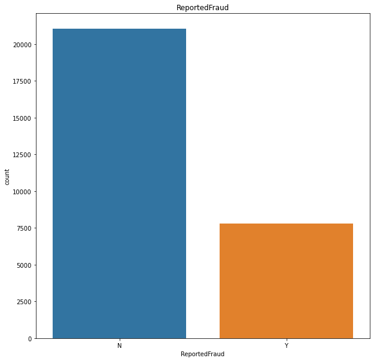

```python
## Target analysis using countplot.

fig = plt.figure(figsize=(10,10))
sns.countplot(df['ReportedFraud']).set_title('ReportedFraud')
```

Target class analysis gives us insight that the N class is in huge number as compared to Y class ,ie, less number of fraud claims are there as compared to legit claims. This type of classification is called imbalanced class classification.

```
array([[<AxesSubplot:title={'center':'IncidentTime'}>,
        <AxesSubplot:title={'center':'NumberOfVehicles'}>,
        <AxesSubplot:title={'center':'BodilyInjuries'}>,
        <AxesSubplot:title={'center':'AmountOfInjuryClaim'}>],
       [<AxesSubplot:title={'center':'AmountOfPropertyClaim'}>,
        <AxesSubplot:title={'center':'AmountOfVehicleDamage'}>,
        <AxesSubplot:title={'center':'InsuredAge'}>,
        <AxesSubplot:title={'center':'InsuredZipCode'}>],
       [<AxesSubplot:title={'center':'CapitalGains'}>,
        <AxesSubplot:title={'center':'CapitalLoss'}>,
        <AxesSubplot:title={'center':'InsurancePolicyNumber'}>,
        <AxesSubplot:title={'center':'CustomerLoyaltyPeriod'}>],
       [<AxesSubplot:title={'center':'Policy_Deductible'}>,
        <AxesSubplot:title={'center':'PolicyAnnualPremium'}>,
        <AxesSubplot:title={'center':'UmbrellaLimit'}>, <AxesSubplot:>]],
      dtype=object)
```

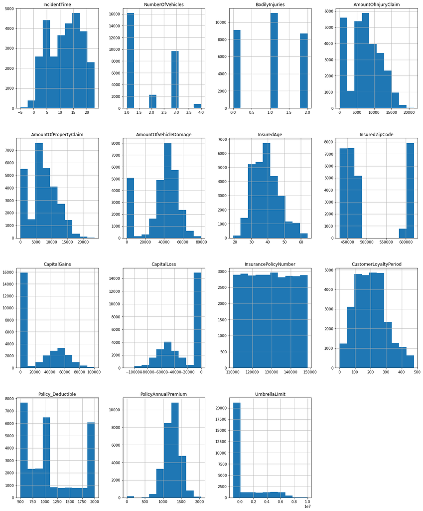

```python
## checking the distribution of data in 15 numerical features using histogram.

fig = plt.figure(figsize=(10,10))
df.hist()
```

Histogram gives us insights on how the data is distributed in these features.

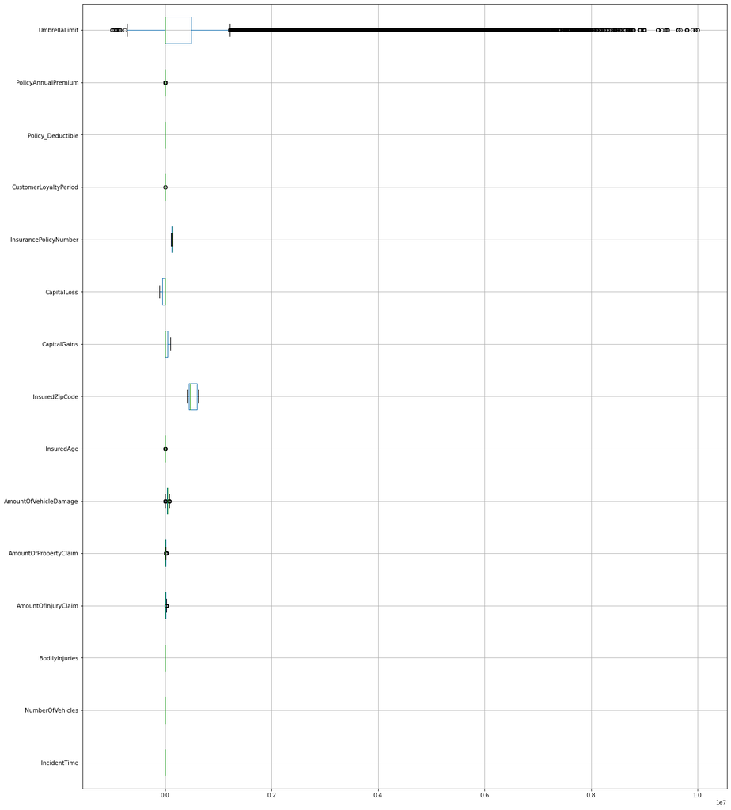

```python
df.plot.box(vert = False, grid = True)   ## Box plot
```

Boxplot gives us insights on how much outliers are their the features. The UmbrellaLimit feature is having more outliers.

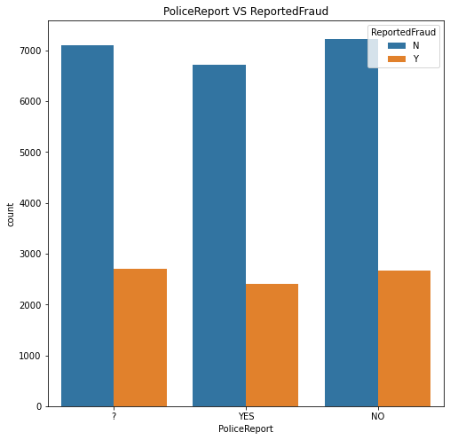

```python
fig = plt.figure(figsize=(8,8))
sns.countplot(df['PoliceReport'], hue = df['ReportedFraud']).set_title('PoliceReport VS ReportedFraud')
```

Insights : More number of fraud claims occured when there is no PoliceReport.

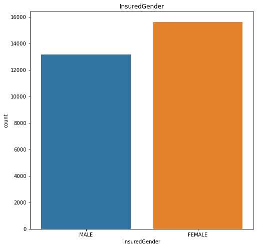

```python
fig = plt.figure(figsize=(8,8))
sns.countplot(df['InsuredGender']).set_title('InsuredGender')
```

Insights : number of females is greater than male in the dataset.

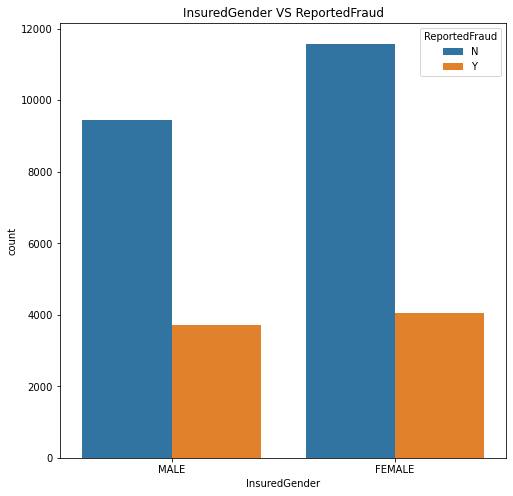

```python
fig = plt.figure(figsize=(8,8))
sns.countplot(df['InsuredGender'], hue = df['ReportedFraud']).set_title('InsuredGender VS ReportedFraud')
```

Insights : More number of fraud claims is done by female than men.

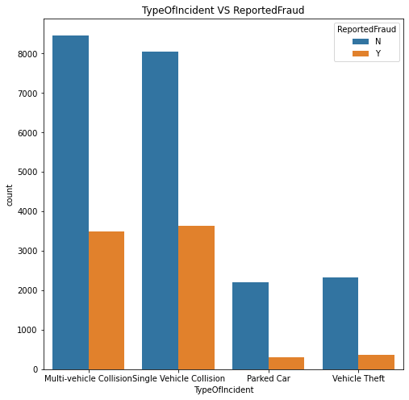

```python
fig = plt.figure(figsize=(8,8))
sns.countplot(df['TypeOfIncident'], hue = df['ReportedFraud']).set_title('TypeOfIncident VS ReportedFraud')
```

Insights : More number of fraud claims occured when TypeofIncident is Single and muti-vehicle collision.

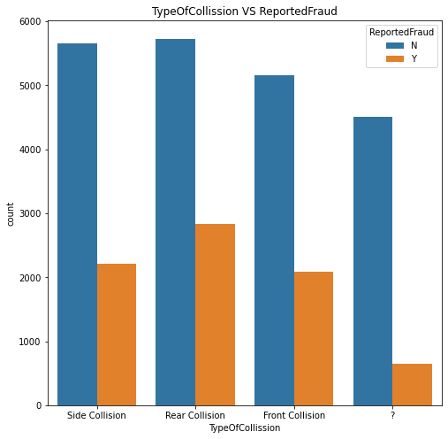

```python
fig = plt.figure(figsize=(8,8))
sns.countplot(df['TypeOfCollission'], hue = df['ReportedFraud']).set_title('TypeOfCollission VS ReportedFraud')
```

Insights : More number of fraud claims occured when there is a Rear Collision of vehicle.

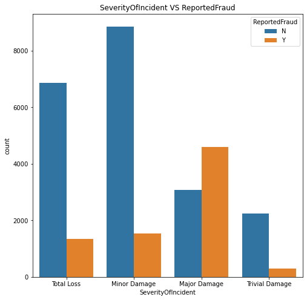

```python
fig = plt.figure(figsize=(8,8))
sns.countplot(df['SeverityOfIncident'], hue = df['ReportedFraud']).set_title('SeverityOfIncident VS ReportedFraud')
```

Insights : More number of fraud claims occured when there is Major damage to the vehicle.

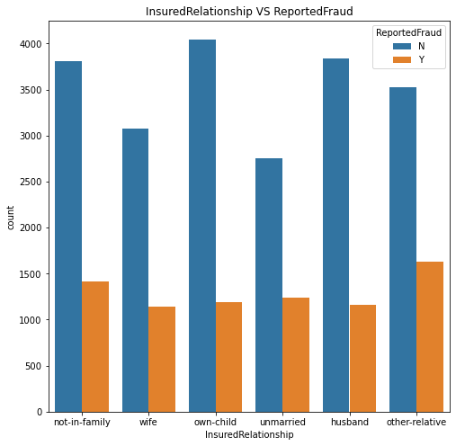

```python
fig = plt.figure(figsize=(8,8))
sns.countplot(df['InsuredRelationship'], hue = df['ReportedFraud']).set_title('InsuredRelationship VS ReportedFraud')
```

Insights : More number of fraud claims occured when there is InsuredRelationship is not-in-family or other relaive.

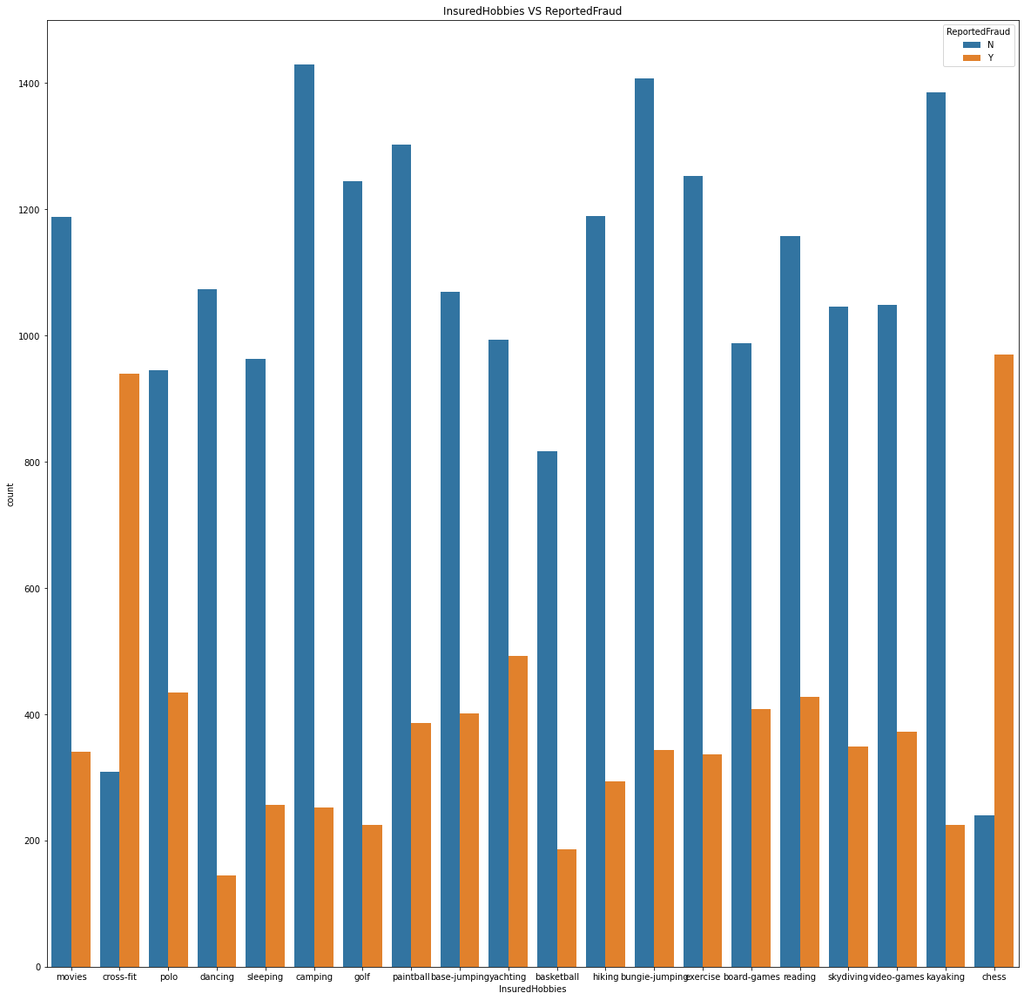

```python
fig = plt.figure(figsize=(20,20))
sns.countplot(df['InsuredHobbies'], hue = df['ReportedFraud']).set_title('InsuredHobbies VS ReportedFraud')
```

Insights : More number of fraud claims occured when the InsuredHobbies are chess and cross-fit

## Features Engineering / Data Cleaning

```python
## Checking for duplicate value in the dataframe

df.duplicated().sum()
```

```
0
```

```python
## Dropping some features which are less important.

df.drop(columns=['CustomerID','VehicleID','Country','DateOfIncident','DateOfPolicyCoverage'], inplace=True)
```

```python
df.shape
```

```
(28836, 37)
```

```python
## Checking for null values in the dataframe

df.isnull().sum()
```

```
TypeOfIncident                 0
TypeOfCollission               0
SeverityOfIncident             0
AuthoritiesContacted           0
IncidentState                  0
IncidentCity                   0
IncidentAddress                0
IncidentTime                   0
NumberOfVehicles               0
PropertyDamage                 0
BodilyInjuries                 0
Witnesses                      0
PoliceReport                   0
AmountOfTotalClaim             0
AmountOfInjuryClaim            0
AmountOfPropertyClaim          0
AmountOfVehicleDamage          0
InsuredAge                     0
InsuredZipCode                 0
InsuredGender                 30
InsuredEducationLevel          0
InsuredOccupation              0
InsuredHobbies                 0
CapitalGains                   0
CapitalLoss                    0
InsurancePolicyNumber          0
CustomerLoyaltyPeriod          0
InsurancePolicyState           0
Policy_CombinedSingleLimit     0
Policy_Deductible              0
PolicyAnnualPremium            0
UmbrellaLimit                  0
InsuredRelationship            0
VehicleMake                    0
VehicleModel                   0
VehicleYOM                     0
ReportedFraud                  0
dtype: int64
```

```python
## Dropping the null values as its less in numbers.

df=df.dropna(axis=0)
```

```python
## Checking again the null value.

df.isnull().sum()
```

```
TypeOfIncident                0
TypeOfCollission              0
SeverityOfIncident            0
AuthoritiesContacted          0
IncidentState                 0
IncidentCity                  0
IncidentAddress               0
IncidentTime                  0
NumberOfVehicles              0
PropertyDamage                0
BodilyInjuries                0
Witnesses                     0
PoliceReport                  0
AmountOfTotalClaim            0
AmountOfInjuryClaim           0
AmountOfPropertyClaim         0
AmountOfVehicleDamage         0
InsuredAge                    0
InsuredZipCode                0
InsuredGender                 0
InsuredEducationLevel         0
InsuredOccupation             0
InsuredHobbies                0
CapitalGains                  0
CapitalLoss                   0
InsurancePolicyNumber         0
CustomerLoyaltyPeriod         0
InsurancePolicyState          0
Policy_CombinedSingleLimit    0
Policy_Deductible             0
PolicyAnnualPremium           0
UmbrellaLimit                 0
InsuredRelationship           0
VehicleMake                   0
VehicleModel                  0
VehicleYOM                    0
ReportedFraud                 0
dtype: int64
```

```python
## checking the value count of each features.


for col in df.columns:
    print(df[col].value_counts())
```

```
Multi-vehicle Collision     11953
Single Vehicle Collision    11664
Vehicle Theft                2683
Parked Car                   2506
Name: TypeOfIncident, dtype: int64
Rear Collision     8550
Side Collision     7855
Front Collision    7243
?                  5158
Name: TypeOfCollission, dtype: int64
Minor Damage      10395
Total Loss         8203
Major Damage       7665
Trivial Damage     2543
Name: SeverityOfIncident, dtype: int64
Police       8313
Fire         6513
Ambulance    5726
Other        5564
None         2690
Name: AuthoritiesContacted, dtype: int64
State5    7875
State7    7164
State9    6158
State8    3175
State4    3024
State6     810
State3     600
Name: IncidentState, dtype: int64
City2    4482
City1    4370
City4    4307
City7    4212
City3    4068
City5    3694
City6    3673
Name: IncidentCity, dtype: int64
Location 1341    73
Location 1254    72
Location 1227    71
```

[output cut: 383 more lines]

```
2000    1545
1999    1520
2001    1455
2012    1355
1998    1318
2013    1271
1997    1151
2014     887
1996     849
1995     555
2015     428
Name: VehicleYOM, dtype: int64
N    21026
Y     7780
Name: ReportedFraud, dtype: int64
```

```python
# As refering the attribute details & value counts, different features having different Symbols as a representation of
# null value. So converting all the symbol to nan by using replce().

df.replace("?",np.nan,inplace=True)             #TypeOfCollission,PropertyDamage,PoliceReport
df.replace("???",np.nan,inplace=True)           # VehicleMake
df.replace(-1,np.nan,inplace=True)              # PolicyAnnualPremium
df.replace("NA",np.nan,inplace=True)            # InsuredGender
df.replace(-5,np.nan,inplace=True)              # IncidentTime
df.replace("MISSINGVALUE",np.nan,inplace=True)  # Witnesses
df.replace("MISSEDDATA",np.nan,inplace=True)    # AmountOfTotalClaim
```

```python
df.isnull().sum()
```

```
TypeOfIncident                    0
TypeOfCollission               5158
SeverityOfIncident                0
AuthoritiesContacted              0
IncidentState                     0
IncidentCity                      0
IncidentAddress                   0
IncidentTime                     31
NumberOfVehicles                  0
PropertyDamage                10450
BodilyInjuries                    0
Witnesses                        46
PoliceReport                   9795
AmountOfTotalClaim               50
AmountOfInjuryClaim               0
AmountOfPropertyClaim             0
AmountOfVehicleDamage             0
InsuredAge                        0
InsuredZipCode                    0
InsuredGender                     0
InsuredEducationLevel             0
InsuredOccupation                 0
InsuredHobbies                    0
CapitalGains                      0
CapitalLoss                       0
InsurancePolicyNumber             0
CustomerLoyaltyPeriod             0
InsurancePolicyState              0
Policy_CombinedSingleLimit        0
Policy_Deductible                 0
PolicyAnnualPremium             141
UmbrellaLimit                     0
InsuredRelationship               0
VehicleMake                      50
VehicleModel                      0
VehicleYOM                        0
ReportedFraud                     0
dtype: int64
```

```python
## As more null value is there in PropertyDamage, PoliceReport, TypeOfCollission. Filling the null values with the mode.

df['PropertyDamage']=df['PropertyDamage'].fillna(df['PropertyDamage'].mode()[0])
df['PoliceReport']=df['PoliceReport'].fillna(df['PoliceReport'].mode()[0])
df['TypeOfCollission']=df['TypeOfCollission'].fillna(df['TypeOfCollission'].mode()[0])
```

```python
## Dropping all the remaining null values as they are less in number.

df=df.dropna(axis=0)
```

```python
## Again checking the null value.

df.isnull().sum()
```

```
TypeOfIncident                0
TypeOfCollission              0
SeverityOfIncident            0
AuthoritiesContacted          0
IncidentState                 0
IncidentCity                  0
IncidentAddress               0
IncidentTime                  0
NumberOfVehicles              0
PropertyDamage                0
BodilyInjuries                0
Witnesses                     0
PoliceReport                  0
AmountOfTotalClaim            0
AmountOfInjuryClaim           0
AmountOfPropertyClaim         0
AmountOfVehicleDamage         0
InsuredAge                    0
InsuredZipCode                0
InsuredGender                 0
InsuredEducationLevel         0
InsuredOccupation             0
InsuredHobbies                0
CapitalGains                  0
CapitalLoss                   0
InsurancePolicyNumber         0
CustomerLoyaltyPeriod         0
InsurancePolicyState          0
Policy_CombinedSingleLimit    0
Policy_Deductible             0
PolicyAnnualPremium           0
UmbrellaLimit                 0
InsuredRelationship           0
VehicleMake                   0
VehicleModel                  0
VehicleYOM                    0
ReportedFraud                 0
dtype: int64
```

```python
## Checking the number of unique values in the features of dataframe.

df.nunique()
```

```
TypeOfIncident                    4
TypeOfCollission                  3
SeverityOfIncident                4
AuthoritiesContacted              5
IncidentState                     7
IncidentCity                      7
IncidentAddress                1000
IncidentTime                     24
NumberOfVehicles                  4
PropertyDamage                    2
BodilyInjuries                    3
Witnesses                         4
PoliceReport                      2
AmountOfTotalClaim            21856
AmountOfInjuryClaim           11911
AmountOfPropertyClaim         11739
AmountOfVehicleDamage         19920
InsuredAge                       46
InsuredZipCode                  995
InsuredGender                     2
InsuredEducationLevel             7
InsuredOccupation                14
InsuredHobbies                   20
CapitalGains                    338
CapitalLoss                     354
InsurancePolicyNumber         28569
CustomerLoyaltyPeriod           479
InsurancePolicyState              3
Policy_CombinedSingleLimit        9
Policy_Deductible              1496
PolicyAnnualPremium           23761
UmbrellaLimit                  7030
InsuredRelationship               6
VehicleMake                      14
VehicleModel                     39
VehicleYOM                       21
ReportedFraud                     2
dtype: int64
```

```python
#Dropped few  more featues

df.drop(columns=['UmbrellaLimit','AmountOfVehicleDamage'], inplace=True)
```

```python
df.shape
```

```
(28569, 35)
```

```python
## Replacing the Y: 1, N:0 of the target class.

df['ReportedFraud'].replace(to_replace='Y', value=1, inplace=True)
df['ReportedFraud'].replace(to_replace='N',  value=0, inplace=True)
```

```python
df.dtypes
```

```
TypeOfIncident                 object
TypeOfCollission               object
SeverityOfIncident             object
AuthoritiesContacted           object
IncidentState                  object
IncidentCity                   object
IncidentAddress                object
IncidentTime                  float64
NumberOfVehicles                int64
PropertyDamage                 object
BodilyInjuries                  int64
Witnesses                      object
PoliceReport                   object
AmountOfTotalClaim             object
AmountOfInjuryClaim             int64
AmountOfPropertyClaim           int64
InsuredAge                      int64
InsuredZipCode                  int64
InsuredGender                  object
InsuredEducationLevel          object
InsuredOccupation              object
InsuredHobbies                 object
CapitalGains                    int64
CapitalLoss                     int64
InsurancePolicyNumber           int64
CustomerLoyaltyPeriod           int64
InsurancePolicyState           object
Policy_CombinedSingleLimit     object
Policy_Deductible               int64
PolicyAnnualPremium           float64
InsuredRelationship            object
VehicleMake                    object
VehicleModel                   object
VehicleYOM                     object
ReportedFraud                   int64
dtype: object
```

```python
## Coping all the numerical features in separate dataframe.

num_df = df.select_dtypes(include=['int64','float64']).copy()
```

```python
num_df.head()
```

|  | IncidentTime | NumberOfVehicles | BodilyInjuries | AmountOfInjuryClaim | AmountOfPropertyClaim | InsuredAge | InsuredZipCode | CapitalGains | CapitalLoss | InsurancePolicyNumber | CustomerLoyaltyPeriod | Policy_Deductible | PolicyAnnualPremium | ReportedFraud |
| --- | --- | --- | --- | --- | --- | --- | --- | --- | --- | --- | --- | --- | --- | --- |
| 0 | 17.0 | 3 | 1 | 13417 | 6071 | 35 | 454776 | 56700 | -48500 | 119121 | 49 | 1000 | 1632.73 | 0 |
| 1 | 10.0 | 3 | 2 | 15560 | 5919 | 36 | 454776 | 70600 | -48500 | 119122 | 114 | 1000 | 1255.19 | 0 |
| 2 | 22.0 | 1 | 2 | 11630 | 11630 | 33 | 603260 | 66400 | -63700 | 119123 | 167 | 617 | 1373.38 | 0 |
| 3 | 22.0 | 1 | 2 | 12003 | 12003 | 36 | 474848 | 47900 | -73400 | 119124 | 190 | 722 | 1337.60 | 0 |
| 4 | 10.0 | 1 | 2 | 8829 | 7234 | 29 | 457942 | 0 | -41500 | 119125 | 115 | 500 | 1353.73 | 0 |

# Detection : IQR (Inter Quartile Range)

```
Data points that lie 1.5 times of IQR above Q3 and below Q1 are outliers

IQR = Quartile3 – Quartile1

Quartile1 =25 percentile of data
Quartile3 =75 percentile of data

upper = Q3 +1.5*IQR
lower = Q1 – 1.5*IQR
```

```python
## Checking for outliers in the numerical features.

for col in num_df:

    q1=np.percentile(num_df[col],25)
    q3=np.percentile(num_df[col],75)

    IQR=q3-q1

    print('Outliers for :',col,'\n')
    #print(q1,q3,IQR)

#detecting upper bounds
    upper=q3+1.5*IQR
    #print('Upper',upper)

    up=num_df[col]>=upper
    #print(np.where(up))


#detectiong lower bounds
    lower=q1-1.5*IQR
    #print('lower',lower)

    lw=num_df[col]<=lower
    #print(np.where(lw),'\n')

    outliers=[]
    for i in num_df[col]:
        if(i<lower or i>upper):
            outliers.append(i)
    print("Outliers are:",outliers)
    print("\n")
```

```
Outliers for : IncidentTime

Outliers are: []


Outliers for : NumberOfVehicles

Outliers are: []


Outliers for : BodilyInjuries

Outliers are: []


Outliers for : AmountOfInjuryClaim

Outliers are: [21450, 21087, 20609, 20749, 20700, 20860, 20246, 21330, 20495, 19719, 19882, 20681, 19925, 21407, 20010, 20699, 21041, 20579, 19384, 20960, 20387, 20263, 20846, 20977, 20654, 20249, 19939, 20602]


Outliers for : AmountOfPropertyClaim

Outliers are: [19950, 21580, 18744, 19417, 19820, 19499, 20288, 18812, 20280, 21799, 21607, 18958, 19020, 21188, 23670, 18583, 20382, 22806, 21810, 19132, 19740, 22393, 21677, 19650, 19221, 21094, 20310, 20902, 21602, 21649, 18803, 19470, 21735, 21681, 21693, 18639, 19115, 18633, 19300, 21562, 19683…


Outliers for : InsuredAge

Outliers are: [61, 62, 61, 64, 63, 64, 61, 61, 61, 62, 62, 61, 61, 61, 62, 62, 61, 61, 62, 62, 62, 61, 63, 61, 61, 61, 61, 61, 61, 63, 61, 61, 61, 61, 63, 61, 61, 61, 61, 61, 64, 63, 62, 61, 63, 61, 61, 61, 64, 61, 62, 61, 63, 61, 61, 62, 62, 61, 61, 61, 61, 62, 61, 61, 61, 61, 61, 61, 62, 61, 62, 6…


Outliers for : InsuredZipCode

Outliers are: []


Outliers for : CapitalGains

Outliers are: []


```

[output cut: 13 more lines]

```


Outliers for : Policy_Deductible

Outliers are: []


Outliers for : PolicyAnnualPremium

Outliers are: [1881.44, 708.64, 538.17, 678.75, 1862.38, 1830.39, 1843.81, 1848.81, 705.88, 1866.02, 1922.84, 1849.55, 1808.73, 1870.64, 701.67, 1890.62, 573.0, 698.52, 1918.0, 1861.52, 2047.59, 597.94, 1835.42, 1865.12, 2041.82, 1876.32, 694.45, 1830.5, 1830.1, 1829.63, 1830.0, 1902.16, 1838.04, 18…


Outliers for : ReportedFraud

Outliers are: []
```

# Outlier_Treatment : Quantile based flooring and capping

```
The data points that are lesser than the 10th percentile are replaced with the 10th percentile value and
the data points that are greater than the 90th percentile are replaced with 90th percentile value.
```

```python
## Outlier treatment


for col in num_df:
    tenth_percentile=np.percentile(num_df[col],10)
    ninetieth_percentile=np.percentile(num_df[col],90)
    print(tenth_percentile,ninetieth_percentile)
    num_df[col]=np.where(num_df[col]<tenth_percentile,tenth_percentile,num_df[col])
    num_df[col]=np.where(num_df[col]>ninetieth_percentile,ninetieth_percentile,num_df[col])
```

```
3.0 20.0
1.0 3.0
0.0 2.0
720.0 13364.0
738.0 13206.0
29.0 50.0
437422.0 614166.0
0.0 63100.0
-64500.0 0.0
113956.8 144768.4
78.0 338.0
500.0 2000.0
996.654 1518.5539999999999
0.0 1.0
```

```python
for col in num_df:

    q1=np.percentile(num_df[col],25)
    q3=np.percentile(num_df[col],75)

    IQR=q3-q1

    print('Outliers for :',col,'\n')
    #print(q1,q3,IQR)

#detecting upper bounds
    upper=q3+1.5*IQR
    #print('Upper',upper)

    up=num_df[col]>=upper
    #print(np.where(up))


#detectiong lower bounds
    lower=q1-1.5*IQR
    #print('lower',lower)

    lw=num_df[col]<=lower
    #print(np.where(lw),'\n')

    outliers=[]
    for i in num_df[col]:
        if(i<lower or i>upper):
            outliers.append(i)
    print("Outliers are:",outliers)
    print("\n")
```

```
Outliers for : IncidentTime

Outliers are: []


Outliers for : NumberOfVehicles

Outliers are: []


Outliers for : BodilyInjuries

Outliers are: []


Outliers for : AmountOfInjuryClaim

Outliers are: []


Outliers for : AmountOfPropertyClaim

Outliers are: []


Outliers for : InsuredAge

Outliers are: []


Outliers for : InsuredZipCode

Outliers are: []


Outliers for : CapitalGains

Outliers are: []


```

[output cut: 13 more lines]

```


Outliers for : Policy_Deductible

Outliers are: []


Outliers for : PolicyAnnualPremium

Outliers are: []


Outliers for : ReportedFraud

Outliers are: []
```

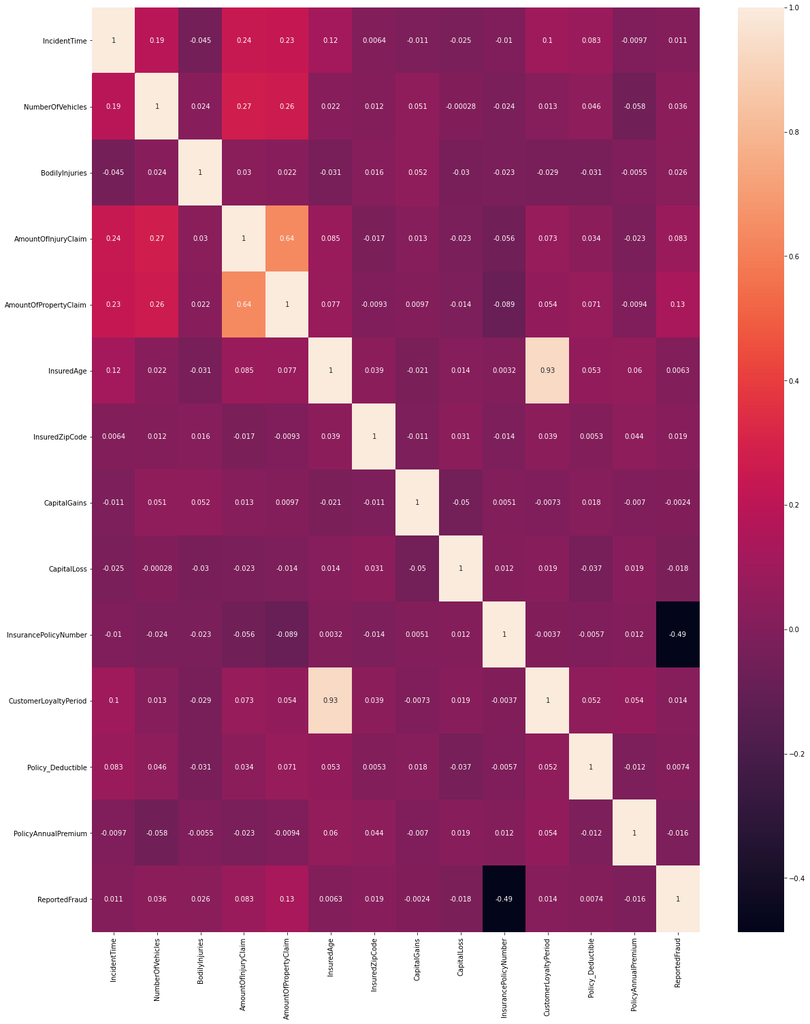

```python
sns.heatmap(num_df.corr(), annot=True )
```

```python
## High coorelation between InsuredAge and CustomerLoyaltyPeriod.

num_df.drop(columns=['InsuredAge'], inplace=True)
```

```python
# Copying the categorical features in new variable.

cat_df = df.select_dtypes(include=['object']).copy()
```

```python
cat_df.head()
```

|  | TypeOfIncident | TypeOfCollission | SeverityOfIncident | AuthoritiesContacted | IncidentState | IncidentCity | IncidentAddress | PropertyDamage | Witnesses | PoliceReport | ... | InsuredGender | InsuredEducationLevel | InsuredOccupation | InsuredHobbies | InsurancePolicyState | Policy_CombinedSingleLimit | InsuredRelationship | VehicleMake | VehicleModel | VehicleYOM |
| --- | --- | --- | --- | --- | --- | --- | --- | --- | --- | --- | --- | --- | --- | --- | --- | --- | --- | --- | --- | --- | --- |
| 0 | Multi-vehicle Collision | Side Collision | Total Loss | Police | State7 | City1 | Location 1311 | NO | 0 | NO | ... | MALE | JD | armed-forces | movies | State1 | 100/300 | not-in-family | Audi | A5 | 2008 |
| 1 | Multi-vehicle Collision | Side Collision | Total Loss | Police | State7 | City5 | Location 1311 | YES | 1 | YES | ... | MALE | JD | tech-support | cross-fit | State1 | 100/300 | not-in-family | Audi | A5 | 2006 |
| 2 | Single Vehicle Collision | Side Collision | Minor Damage | Other | State8 | City6 | Location 2081 | YES | 3 | NO | ... | MALE | JD | armed-forces | polo | State3 | 500/1000 | wife | Volkswagen | Jetta | 1999 |
| 3 | Single Vehicle Collision | Side Collision | Minor Damage | Other | State9 | City6 | Location 2081 | YES | 3 | NO | ... | MALE | JD | armed-forces | polo | State2 | 500/1000 | own-child | Volkswagen | Jetta | 2003 |
| 4 | Single Vehicle Collision | Rear Collision | Minor Damage | Fire | State8 | City6 | Location 1695 | NO | 1 | YES | ... | FEMALE | High School | exec-managerial | dancing | State2 | 100/300 | unmarried | Toyota | CRV | 2010 |

5 rows × 21 columns

```python
for col in cat_df.columns:
    print(col,':', len(cat_df[col].unique()), 'labels')
```

```
TypeOfIncident : 4 labels
TypeOfCollission : 3 labels
SeverityOfIncident : 4 labels
AuthoritiesContacted : 5 labels
IncidentState : 7 labels
IncidentCity : 7 labels
IncidentAddress : 1000 labels
PropertyDamage : 2 labels
Witnesses : 4 labels
PoliceReport : 2 labels
AmountOfTotalClaim : 21856 labels
InsuredGender : 2 labels
InsuredEducationLevel : 7 labels
InsuredOccupation : 14 labels
InsuredHobbies : 20 labels
InsurancePolicyState : 3 labels
Policy_CombinedSingleLimit : 9 labels
InsuredRelationship : 6 labels
VehicleMake : 14 labels
VehicleModel : 39 labels
VehicleYOM : 21 labels
```

```python
### Applying One hot encoding to convert categorical features to numerical features.

enc_df = pd.get_dummies(cat_df, columns =['TypeOfIncident', 'AuthoritiesContacted','Witnesses','InsurancePolicyState',
                        'PropertyDamage','TypeOfCollission', 'SeverityOfIncident',
                            'InsuredRelationship','PoliceReport', 'InsuredGender'], drop_first = True)

enc_df.head()
```

|  | IncidentState | IncidentCity | IncidentAddress | AmountOfTotalClaim | InsuredEducationLevel | InsuredOccupation | InsuredHobbies | Policy_CombinedSingleLimit | VehicleMake | VehicleModel | ... | SeverityOfIncident_Minor Damage | SeverityOfIncident_Total Loss | SeverityOfIncident_Trivial Damage | InsuredRelationship_not-in-family | InsuredRelationship_other-relative | InsuredRelationship_own-child | InsuredRelationship_unmarried | InsuredRelationship_wife | PoliceReport_YES | InsuredGender_MALE |
| --- | --- | --- | --- | --- | --- | --- | --- | --- | --- | --- | --- | --- | --- | --- | --- | --- | --- | --- | --- | --- | --- |
| 0 | State7 | City1 | Location 1311 | 65501 | JD | armed-forces | movies | 100/300 | Audi | A5 | ... | 0 | 1 | 0 | 1 | 0 | 0 | 0 | 0 | 0 | 1 |
| 1 | State7 | City5 | Location 1311 | 61382 | JD | tech-support | cross-fit | 100/300 | Audi | A5 | ... | 0 | 1 | 0 | 1 | 0 | 0 | 0 | 0 | 1 | 1 |
| 2 | State8 | City6 | Location 2081 | 66755 | JD | armed-forces | polo | 500/1000 | Volkswagen | Jetta | ... | 1 | 0 | 0 | 0 | 0 | 0 | 0 | 1 | 0 | 1 |
| 3 | State9 | City6 | Location 2081 | 66243 | JD | armed-forces | polo | 500/1000 | Volkswagen | Jetta | ... | 1 | 0 | 0 | 0 | 0 | 1 | 0 | 0 | 0 | 1 |
| 4 | State8 | City6 | Location 1695 | 53544 | High School | exec-managerial | dancing | 100/300 | Toyota | CRV | ... | 1 | 0 | 0 | 0 | 0 | 0 | 1 | 0 | 1 | 0 |

5 rows × 36 columns

```python
## Dropping the features which are having more unique labels and seems not important.

enc_df.drop(columns =['IncidentState','IncidentCity','InsuredEducationLevel','InsuredOccupation',
                      'InsuredHobbies','Policy_CombinedSingleLimit',
                     'VehicleMake','VehicleModel','VehicleYOM','IncidentAddress','AmountOfTotalClaim'], inplace = True)
```

```python
## Concating the num_df and enc_df.

df1 =pd.concat([enc_df,num_df], axis=1)
```

```python
## converting all the features  datatypes to float64.

df1 = df1.astype('float64')
```

```python
df1.dtypes
```

```
TypeOfIncident_Parked Car                  float64
TypeOfIncident_Single Vehicle Collision    float64
TypeOfIncident_Vehicle Theft               float64
AuthoritiesContacted_Fire                  float64
AuthoritiesContacted_None                  float64
AuthoritiesContacted_Other                 float64
AuthoritiesContacted_Police                float64
Witnesses_1                                float64
Witnesses_2                                float64
Witnesses_3                                float64
InsurancePolicyState_State2                float64
InsurancePolicyState_State3                float64
PropertyDamage_YES                         float64
TypeOfCollission_Rear Collision            float64
TypeOfCollission_Side Collision            float64
SeverityOfIncident_Minor Damage            float64
SeverityOfIncident_Total Loss              float64
SeverityOfIncident_Trivial Damage          float64
InsuredRelationship_not-in-family          float64
InsuredRelationship_other-relative         float64
InsuredRelationship_own-child              float64
InsuredRelationship_unmarried              float64
InsuredRelationship_wife                   float64
PoliceReport_YES                           float64
InsuredGender_MALE                         float64
IncidentTime                               float64
NumberOfVehicles                           float64
BodilyInjuries                             float64
AmountOfInjuryClaim                        float64
AmountOfPropertyClaim                      float64
InsuredZipCode                             float64
CapitalGains                               float64
CapitalLoss                                float64
InsurancePolicyNumber                      float64
CustomerLoyaltyPeriod                      float64
Policy_Deductible                          float64
PolicyAnnualPremium                        float64
ReportedFraud                              float64
dtype: object
```

```python
df1.head()
```

|  | TypeOfIncident_Parked Car | TypeOfIncident_Single Vehicle Collision | TypeOfIncident_Vehicle Theft | AuthoritiesContacted_Fire | AuthoritiesContacted_None | AuthoritiesContacted_Other | AuthoritiesContacted_Police | Witnesses_1 | Witnesses_2 | Witnesses_3 | ... | AmountOfInjuryClaim | AmountOfPropertyClaim | InsuredZipCode | CapitalGains | CapitalLoss | InsurancePolicyNumber | CustomerLoyaltyPeriod | Policy_Deductible | PolicyAnnualPremium | ReportedFraud |
| --- | --- | --- | --- | --- | --- | --- | --- | --- | --- | --- | --- | --- | --- | --- | --- | --- | --- | --- | --- | --- | --- |
| 0 | 0.0 | 0.0 | 0.0 | 0.0 | 0.0 | 0.0 | 1.0 | 0.0 | 0.0 | 0.0 | ... | 13364.0 | 6071.0 | 454776.0 | 56700.0 | -48500.0 | 119121.0 | 78.0 | 1000.0 | 1518.554 | 0.0 |
| 1 | 0.0 | 0.0 | 0.0 | 0.0 | 0.0 | 0.0 | 1.0 | 1.0 | 0.0 | 0.0 | ... | 13364.0 | 5919.0 | 454776.0 | 63100.0 | -48500.0 | 119122.0 | 114.0 | 1000.0 | 1255.190 | 0.0 |
| 2 | 0.0 | 1.0 | 0.0 | 0.0 | 0.0 | 1.0 | 0.0 | 0.0 | 0.0 | 1.0 | ... | 11630.0 | 11630.0 | 603260.0 | 63100.0 | -63700.0 | 119123.0 | 167.0 | 617.0 | 1373.380 | 0.0 |
| 3 | 0.0 | 1.0 | 0.0 | 0.0 | 0.0 | 1.0 | 0.0 | 0.0 | 0.0 | 1.0 | ... | 12003.0 | 12003.0 | 474848.0 | 47900.0 | -64500.0 | 119124.0 | 190.0 | 722.0 | 1337.600 | 0.0 |
| 4 | 0.0 | 1.0 | 0.0 | 1.0 | 0.0 | 0.0 | 0.0 | 1.0 | 0.0 | 0.0 | ... | 8829.0 | 7234.0 | 457942.0 | 0.0 | -41500.0 | 119125.0 | 115.0 | 500.0 | 1353.730 | 0.0 |

5 rows × 38 columns

```python
df1.shape
```

```
(28569, 38)
```

```python
## Splitting the independent features and target class and storing in two different variables.

X = df1.drop(columns = 'ReportedFraud', axis=1)
y = df1['ReportedFraud']
```

```python
## standardizing the values of X-train using StandardScaler().

scaler = StandardScaler()
scaled_data = scaler.fit_transform(X)
X = scaled_data
```

```python
## Splitting the dataframe into train and test dataframe with proportion of 80:20.

X_train, X_test, y_train, y_test = train_test_split(X, y, test_size=0.2, random_state=7,stratify=y)
```